# SnifferBike - Exploratory Data Analysis

**by: Nicolás Salazar Beltrán ([nicolas-salbe.github.io](https://nicolas-salbe.github.io/))**

The SnifferBike is a data collection project with the objective of getting insights on air quality and cycling routes use in the province of Utrecht. Data is collected through an IoT sensing system mounted on the bicycles of participating citizens.

### Data Description

The *datawoordenboek_snuffelfiets* dataset gathers the data collected from 190 sensors deployed during 1 week in February 2020 in the province of Utrecht.

### Data Dictionary

- **_id**: The identifier of the sample measurement.
- **sensor**: The identifier of the sensor taking the measurement.
- **geom**: ?
- **line**: ?
- **recording_timestamp**: Timestamp of the measurement.
- **date_recording**: Date of the measurement.
- **delta_recording_time**: Time since previous measurement (s).
- **trip_sequence**: ?
- **receive_time**: Timestamp of when the measurement data was received.
- **horizontal_accuracy**: GPS horizontal accuracy (mm?).
- **humidity**: Relative humidity (%).
- **pm10**: Particulate matter smaller than 10 micrometers (ug/m^3).
- **pm1_0**: Particulate matter smaller than 1.0 micrometers (ug/m^3).
- **pm2_5**: Particulate matter smaller than 2.5 micrometers (ug/m^3).
- **pressure**: Barometric pressure (Pa).
- **temperature**: Temperature (degC).
- **vertical_accuracy**: GPS vertical accuracy (mm?).
- **voc**: Volatile Organic Compounds (ppb?).
- **voltage**: Battery voltage (V).
- **error_code**: Error code.
- **version_major**: FW version major.
- **version_minor**: Fw version minor.
- **acc_max**: Max acceleration (m/s^2?).
- **no2**: Nitrogen dioxide (ppb?).
- **distance_to_previous**: Distance traveled since previous measurement (m)?
- **cumulative_distance**: Cumulative distance traveled since power on?
- **speed_km_h**: Speed (km/h)

### Analysis

```python
import numpy as np
import pandas as pd

import matplotlib.pyplot as plt
import seaborn as sns
```

#### Data Structure

```python
df = pd.read_csv('datawoordenboek_snuffelfiets.csv', delimiter= ';')
df.head()
```

|  | _id | sensor | geom | line | recording_timestamp | date_recording | delta_recording_time | trip_sequence | receive_time | horizontal_accuracy | ... | voc | voltage | error_code | version_major | version_minor | acc_max | no2 | distance_to_previous | cumulative_distance | speed_km_h |
| --- | --- | --- | --- | --- | --- | --- | --- | --- | --- | --- | --- | --- | --- | --- | --- | --- | --- | --- | --- | --- | --- |
| 0 | 3478092 | 2ff12c7d72b4860441ddb28da271abcf | 0101000020E6100000FDFFFFDFE1DE1440000000A04B0C... | 0102000020E610000002000000FDFFFFDFE1DE14400000... | 2020-02-11 09:04:11 | 2020-02-11 | 110 | 885 | 2020-02-11 09:05:03.971 | 27635 | ... | 51 | 4.15 | 0 | 1 | 3 | 0 | 1130 | 213.559902 | 305.763370 | 6.989233 |
| 1 | 3478094 | 2ff12c7d72b4860441ddb28da271abcf | 0101000020E6100000FFFFFF5F6ADF144006000040650C... | 0102000020E610000002000000FFFFFF5F6ADF14400600... | 2020-02-11 09:04:33 | 2020-02-11 | 22 | 885 | 2020-02-11 09:05:04.005 | 33052 | ... | 56 | 4.15 | 0 | 1 | 3 | 0 | 1087 | 94.046720 | 409.838533 | 15.389463 |
| 2 | 3478096 | 2ff12c7d72b4860441ddb28da271abcf | 0101000020E6100000FCFFFF3F3CE01440FAFFFFBF820C... | 0102000020E610000002000000FCFFFF3F3CE01440FAFF... | 2020-02-11 09:04:55 | 2020-02-11 | 22 | 885 | 2020-02-11 09:05:03.994 | 38635 | ... | 62 | 4.14 | 0 | 1 | 3 | 0 | 1048 | 114.213093 | 543.252543 | 18.689415 |
| 3 | 3478098 | 2ff12c7d72b4860441ddb28da271abcf | 0101000020E6100000FBFFFF5F30E1144000000060980C... | 0102000020E610000002000000FBFFFF5F30E114400000... | 2020-02-11 09:05:17 | 2020-02-11 | 22 | 885 | 2020-02-11 09:05:56.719 | 27490 | ... | 67 | 4.14 | 0 | 1 | 3 | 0 | 1032 | 97.287311 | 669.577574 | 15.919742 |
| 4 | 3478100 | 2ff12c7d72b4860441ddb28da271abcf | 0101000020E61000000200008008E2144000000000B00C... | 0102000020E6100000020000000200008008E214400000... | 2020-02-11 09:05:39 | 2020-02-11 | 22 | 885 | 2020-02-11 09:05:56.746 | 28046 | ... | 72 | 4.15 | 0 | 1 | 3 | 0 | 1006 | 98.120251 | 790.823659 | 16.056041 |

5 rows × 27 columns

```python
df.tail()
```

|  | _id | sensor | geom | line | recording_timestamp | date_recording | delta_recording_time | trip_sequence | receive_time | horizontal_accuracy | ... | voc | voltage | error_code | version_major | version_minor | acc_max | no2 | distance_to_previous | cumulative_distance | speed_km_h |
| --- | --- | --- | --- | --- | --- | --- | --- | --- | --- | --- | --- | --- | --- | --- | --- | --- | --- | --- | --- | --- | --- |
| 95842 | 29264324 | 157de770dd1f9846b5ef5288d905497c | 0101000020E6100000020000E009331640010000208101... | 0102000020E610000002000000020000E0093316400100... | 2020-02-16 18:20:57 | 2020-02-16 | 14 | 48 | 2020-02-16 18:20:50.321 | 6944 | ... | 51 | 3.97 | 0 | 1 | 6 | 0 | 0 | 81.941300 | 4399.009526 | 21.070620 |
| 95843 | 29264325 | 157de770dd1f9846b5ef5288d905497c | 0101000020E6100000FCFFFF5F6E321640FCFFFFFF6801... | 0102000020E610000002000000FCFFFF5F6E321640FCFF... | 2020-02-16 18:21:11 | 2020-02-16 | 14 | 48 | 2020-02-16 18:20:50.337 | 5500 | ... | 51 | 3.96 | 0 | 1 | 6 | 2 | 0 | 91.485364 | 4503.688179 | 23.524808 |
| 95844 | 29264326 | 157de770dd1f9846b5ef5288d905497c | 0101000020E6100000FEFFFF3F81321640010000205101... | 0102000020E610000002000000FEFFFF3F813216400100... | 2020-02-16 18:21:26 | 2020-02-16 | 15 | 48 | 2020-02-16 18:23:25.035 | 5049 | ... | 52 | 3.95 | 0 | 1 | 6 | 0 | 0 | 81.220941 | 4584.810472 | 19.493026 |
| 95845 | 29264327 | 157de770dd1f9846b5ef5288d905497c | 0101000020E6100000FEFFFF3FA1321640060000403901... | 0102000020E610000002000000FEFFFF3FA13216400600... | 2020-02-16 18:21:40 | 2020-02-16 | 14 | 48 | 2020-02-16 18:23:25.065 | 3994 | ... | 52 | 3.96 | 0 | 1 | 6 | 0 | 0 | 81.502461 | 4666.661868 | 20.957776 |
| 95846 | 29264328 | 157de770dd1f9846b5ef5288d905497c | 0101000020E6100000FDFFFF1F4F321640010000202501... | 0102000020E610000002000000FDFFFF1F4F3216400100... | 2020-02-16 18:21:54 | 2020-02-16 | 14 | 48 | 2020-02-16 18:23:25.085 | 5204 | ... | 52 | 3.96 | 0 | 1 | 6 | 0 | 0 | 71.642464 | 4743.023342 | 18.422348 |

5 rows × 27 columns

```python
df.shape
```

```
(95847, 27)
```

```python
df.dtypes
```

```
_id                       int64
sensor                   object
geom                     object
line                     object
recording_timestamp      object
date_recording           object
delta_recording_time      int64
trip_sequence             int64
receive_time             object
horizontal_accuracy       int64
humidity                  int64
pm10                      int64
pm1_0                     int64
pm2_5                     int64
pressure                  int64
temperature             float64
vertical_accuracy         int64
voc                       int64
voltage                 float64
error_code                int64
version_major             int64
version_minor             int64
acc_max                   int64
no2                       int64
distance_to_previous    float64
cumulative_distance     float64
speed_km_h              float64
dtype: object
```

- Most of the variables are numerical while there are only a few strings.

```python
df.isnull().sum()
```

```
_id                     0
sensor                  0
geom                    0
line                    0
recording_timestamp     0
date_recording          0
delta_recording_time    0
trip_sequence           0
receive_time            0
horizontal_accuracy     0
humidity                0
pm10                    0
pm1_0                   0
pm2_5                   0
pressure                0
temperature             0
vertical_accuracy       0
voc                     0
voltage                 0
error_code              0
version_major           0
version_minor           0
acc_max                 0
no2                     0
distance_to_previous    0
cumulative_distance     0
speed_km_h              0
dtype: int64
```

```python
df.isna().sum()
```

```
_id                     0
sensor                  0
geom                    0
line                    0
recording_timestamp     0
date_recording          0
delta_recording_time    0
trip_sequence           0
receive_time            0
horizontal_accuracy     0
humidity                0
pm10                    0
pm1_0                   0
pm2_5                   0
pressure                0
temperature             0
vertical_accuracy       0
voc                     0
voltage                 0
error_code              0
version_major           0
version_minor           0
acc_max                 0
no2                     0
distance_to_previous    0
cumulative_distance     0
speed_km_h              0
dtype: int64
```

- There are no null nor na values in the dataset.

Let's check for repeated data values throughout the columns.

```python
df.nunique()
```

```
_id                     95847
sensor                    190
geom                    95835
line                    95847
recording_timestamp     79240
date_recording              7
delta_recording_time      251
trip_sequence             650
receive_time            90339
horizontal_accuracy     13788
humidity                   75
pm10                      312
pm1_0                     288
pm2_5                     302
pressure                  234
temperature               235
vertical_accuracy       16245
voc                       461
voltage                    72
error_code                  9
version_major               1
version_minor               3
acc_max                    26
no2                       115
distance_to_previous    95846
cumulative_distance     95847
speed_km_h              95846
dtype: int64
```

- The *_id* column is just an identifier of each record and doesn't carry relevant info for the analysis. Also, *geom* and *line* might be GPS coded data not useful for analysis.

Let's drop these columns.

```python
df.drop(['_id','geom','line'], axis=1, inplace=True)
```

Regarding *trip_sequence* it is not clear what it means. Do different trips of the same sensor are indicated by this sequence? Can different sensors have the same trip sequence? From the data it is observed that theres's a progression in the trip sequence for each sensor. However, the trip sequence identifier is not unique among sensors.

Data is coming from 190 different sensor units. Let's store the IDs of these sensors in an array.

```python
sensor_array = df.sensor.unique()
```

The *date_recording* column seems to indicate that data was taken during 1 week (7 days). Let's double check this.

```python
df['date_recording'].unique()
```

```
array(['2020-02-11', '2020-02-12', '2020-02-13', '2020-02-14',
       '2020-02-15', '2020-02-10', '2020-02-16'], dtype=object)
```

So the data was recorded from February 10, 2020 to February 16, 2020, just before the pandemic!

The SnifferBike sensor sends the measurement data to a cloud server with a certain regularity. For this analysis, the timestamp of when the data is received by the server is not relevant so we can drop *receive_time*. However, in a different analysis it might be worth to understand how this client-server communication can be opmitized to save energy from the battery.

Variable *error_code* is most likely an enumeration coding different errors that detected by the sensor firmware. Let's see which of these codes are present.

```python
df['error_code'].unique()
```

```
array([   0, 2048,  516,   32, 2080,  128, 2176, 2688, 2592], dtype=int64)
```

- The error code seems to be a bitwise coded error. They could indicate a wrong measurement or an LTE Tx/Rx issue.

All the sensors are running FW version major 1.0. However, there are some running FW version minor 0.3, 0.5, or 0.6.

#### Statistics

Let's get some insight on the statistics of the numerical data.

```python
df.describe()
```

|  | delta_recording_time | trip_sequence | horizontal_accuracy | humidity | pm10 | pm1_0 | pm2_5 | pressure | temperature | vertical_accuracy | voc | voltage | error_code | version_major | version_minor | acc_max | no2 | distance_to_previous | cumulative_distance | speed_km_h |
| --- | --- | --- | --- | --- | --- | --- | --- | --- | --- | --- | --- | --- | --- | --- | --- | --- | --- | --- | --- | --- |
| count | 95847.000000 | 95847.000000 | 95847.000000 | 95847.000000 | 95847.000000 | 95847.000000 | 95847.000000 | 95847.000000 | 95847.000000 | 95847.000000 | 95847.000000 | 95847.000000 | 95847.00000 | 95847.0 | 95847.000000 | 95847.000000 | 95847.000000 | 95847.000000 | 95847.000000 | 95847.000000 |
| mean | 15.319092 | 277.798773 | 5310.158628 | 62.102570 | 193.032792 | 47.401285 | 127.860997 | 990.927050 | 12.679368 | 7035.739241 | 103.920832 | 3.892999 | 261.84878 | 1.0 | 5.830887 | 0.115622 | 0.471992 | 72.416874 | 6461.031326 | 17.967867 |
| std | 14.425905 | 174.517458 | 5054.975466 | 12.501207 | 3756.916883 | 898.628401 | 2480.058163 | 68.594009 | 17.913468 | 6638.467009 | 70.314422 | 0.132570 | 683.63004 | 0.0 | 0.434561 | 0.604902 | 15.894625 | 70.971627 | 6749.184528 | 5.753131 |
| min | 10.000000 | 12.000000 | 943.000000 | 0.000000 | 0.000000 | 0.000000 | 0.000000 | 0.000000 | 0.000000 | 1433.000000 | 0.000000 | 3.300000 | 0.00000 | 1.0 | 3.000000 | 0.000000 | 0.000000 | 0.196070 | 201.101991 | 0.008403 |
| 25% | 13.000000 | 158.000000 | 2985.000000 | 53.000000 | 2.000000 | 1.000000 | 2.000000 | 988.000000 | 8.500000 | 4043.000000 | 46.000000 | 3.770000 | 0.00000 | 1.0 | 6.000000 | 0.000000 | 0.000000 | 53.268280 | 1850.566514 | 14.671446 |
| 50% | 13.000000 | 227.000000 | 4067.000000 | 63.000000 | 4.000000 | 1.000000 | 3.000000 | 998.000000 | 10.200000 | 5428.000000 | 94.000000 | 3.880000 | 0.00000 | 1.0 | 6.000000 | 0.000000 | 0.000000 | 66.895496 | 4358.089962 | 18.012631 |
| 75% | 14.000000 | 350.000000 | 5831.000000 | 71.000000 | 6.000000 | 2.000000 | 4.000000 | 1011.000000 | 12.900000 | 7750.000000 | 143.000000 | 4.010000 | 0.00000 | 1.0 | 6.000000 | 0.000000 | 0.000000 | 81.963765 | 8549.229746 | 21.828326 |
| max | 300.000000 | 2475.000000 | 86061.000000 | 96.000000 | 88958.000000 | 20368.000000 | 58296.000000 | 1064.000000 | 197.800000 | 96222.000000 | 1104.000000 | 5.550000 | 2688.00000 | 1.0 | 6.000000 | 59.000000 | 1130.000000 | 5117.835973 | 53813.413919 | 108.339024 |

### Univariate Analysis

#### Categorical variables

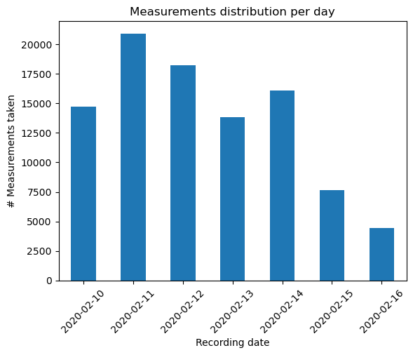

```python
# Measurements distribution per day
df['date_recording'].value_counts().sort_index().plot(kind='bar', rot=0)
plt.title('Measurements distribution per day')
plt.xlabel('Recording date')
plt.xticks(rotation=45)
plt.ylabel('# Measurements taken')
plt.show()
```

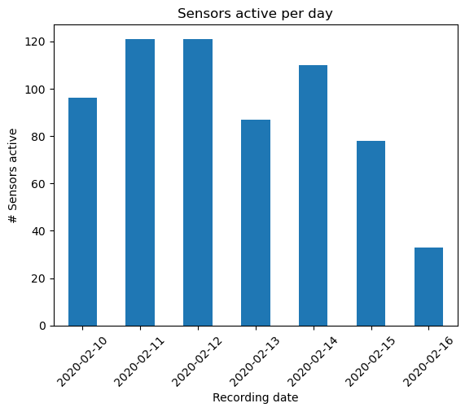

```python
# Sensor activity distribution per day
df.groupby('date_recording')['sensor'].nunique().plot(kind='bar', rot=0)
plt.title('Sensors active per day')
plt.xlabel('Recording date')
plt.xticks(rotation=45)
plt.ylabel('# Sensors active')
plt.show()
```

During this week, most of the measurements happened on a Tuesday (11-02) while during the weekend the meaurements decreased signficantly. This is expected as people ride their bicycles more often during the week to go to work or school. Also, there might be people not using their bicycles at all during some days in the week. Let's get some insight on the bicycle use distribution per this week.

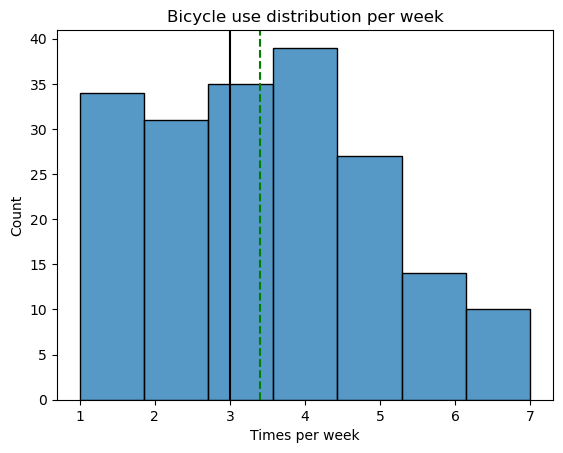

```python
days_per_week = pd.Series(df.groupby('sensor')['date_recording'].nunique())
ax = sns.histplot(x=days_per_week, kde=False, bins=7)
ax.axvline(np.mean(days_per_week), color='g', linestyle='--')      # Add mean to the histogram
ax.axvline(np.median(days_per_week), color='black', linestyle='-') # Add median to the histogram
plt.title('Bicycle use distribution per week')
plt.xlabel('Times per week')
plt.ylabel('Count')
plt.show()
```

So assuming there's one rider per SnifferBike sensor, most of the people used their bicycle 4 times per week. Surprisingly, also many people only used their bicycle once or twice. This makes the distribution not normal and the average SnifferBike use is 3.4 times per week. There's a good opportunity for improvement here.

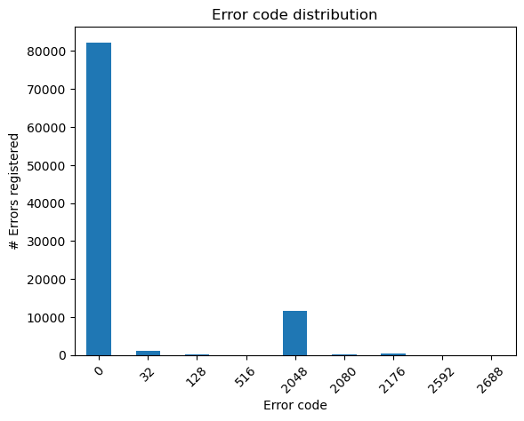

```python
# Error codes distribution
df['error_code'].value_counts().sort_index().plot(kind='bar', rot=0)
plt.title('Error code distribution')
plt.xlabel('Error code')
plt.xticks(rotation=45)
plt.ylabel('# Errors registered')
plt.show()
```

### Numerical variables

Let's check if the measurements are mostly taken while moving or during standstill.

```python
dist = df.groupby(by=['sensor','date_recording']).agg({'recording_timestamp':'unique','cumulative_distance':'unique'})
```

```python
import matplotlib.dates as md
def plot_cumulative_distance_vs_time(sensor):
    sensor_df = dist.loc[sensor]
    date_index = sensor_df.index
    plt.figure(figsize = (12, 30))
    for index, date in enumerate(date_index):
        x = sensor_df.loc[date].recording_timestamp
        y = sensor_df.loc[date].cumulative_distance
        plt.subplot(len(date_index), 1, index+1)
        plt.plot(x, y, 'bo--', label=date)
        plt.title(f'Date: {date}')
        plt.xlabel('Time')
        plt.xticks(rotation=45)
        plt.gcf().axes[index].xaxis.set_major_locator(md.MinuteLocator(interval=15))
        plt.gcf().axes[index].xaxis.set_major_formatter(md.DateFormatter("%H:%M:%S"))
        plt.ylabel('Cumulative distance (m)')

    plt.suptitle(f'Cumulative distance per day \n Sensor: {sensor}', size=16)
    plt.tight_layout()
    plt.subplots_adjust(top=0.92)
    plt.show()
```

The next figure shows the cumulative distance ridden by the user who's carrying *sensor_id=2ff12c7d72b4860441ddb28da271abcf* per day.

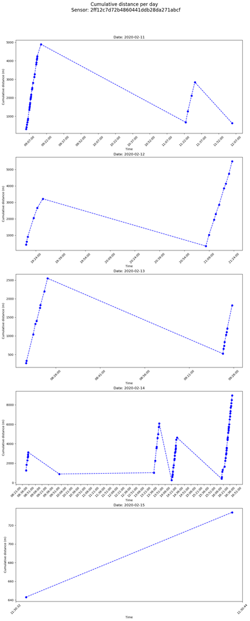

```python
plot_cumulative_distance_vs_time(sensor_array[0])
```

```python
def calculate_n_trips(x):
    n_trips = 1
    for i in range(len(x)-1):
        if x[i + 1] < x[i]:
            n_trips = n_trips + 1
    return n_trips
```

```python
dist['n_trips'] = dist['cumulative_distance'].apply(calculate_n_trips)
```

Let's now get some insight on the distribution of the bicycle trips assuming that the logged *cumulative_distance* is reset every time movement is detected again.

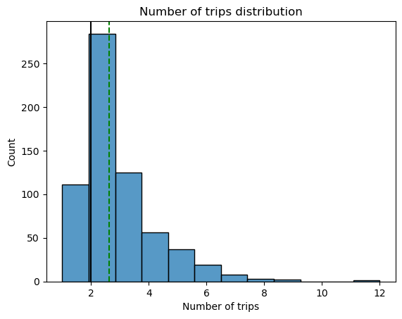

```python
ax = sns.histplot(dist.n_trips, bins=12)
ax.axvline(np.mean(dist.n_trips), color='g', linestyle='--')      # Add mean to the histogram
ax.axvline(np.median(dist.n_trips), color='black', linestyle='-') # Add median to the histogram
plt.title('Number of trips distribution')
plt.xlabel('Number of trips')
plt.ylabel('Count')
plt.show()
```

- So overall, the median number of trips during the week is 2 and the mean is 2.6. Therefore, it is possible to assume that most of the SnifferBike users ride their bicycles only for a single round-trip per day.

Let's dive more into the detail of the trips distribution per day.

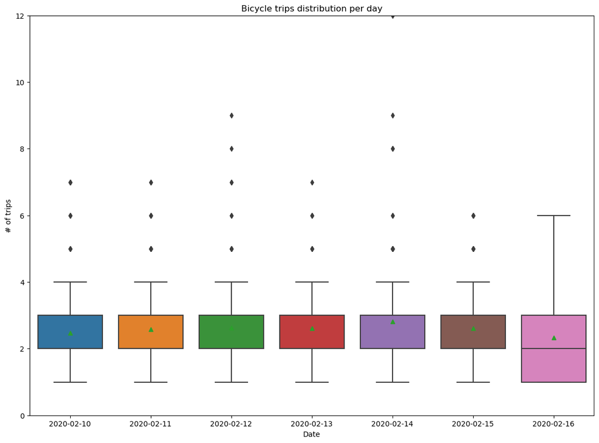

```python
plt.figure(figsize=(14,10))
date_order = ['2020-02-10', '2020-02-11', '2020-02-12', '2020-02-13', '2020-02-14', '2020-02-15', '2020-02-16']
sns.boxplot(data=alt_dist, x='date_recording', y='n_trips', showmeans=True, order=date_order)
plt.title('Bicycle trips distribution per day')
plt.xlabel('Date')
plt.ylabel('# of trips')
plt.ylim(0,12)
plt.show()
```

#### Air Quality

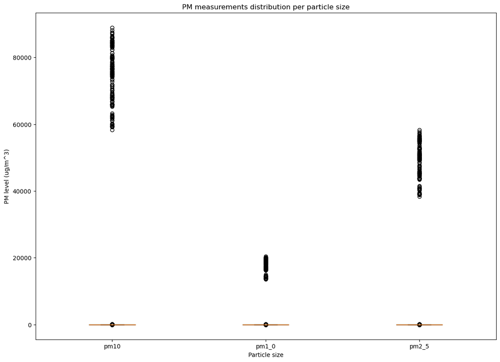

```python
plt.figure(figsize=(14,10))
aq_features = air_quality_df[air_quality_df.columns[:3]]
plt.boxplot(x=aq_features)
plt.title('PM measurements distribution per particle size')
plt.xlabel('Particle size')
plt.xticks([1, 2, 3], air_quality_df.columns[:3])
plt.ylabel('PM level (ug/m^3)')
plt.show()
```

- The above plot shows the PM measurements distribution when *error_code=0*. The PM measurements indeed have plenty of outliers that affect the mean value calculation. This could be due to faulty sensors or data corruption. Let's zoom in into this plot an get some more realistic statistics.

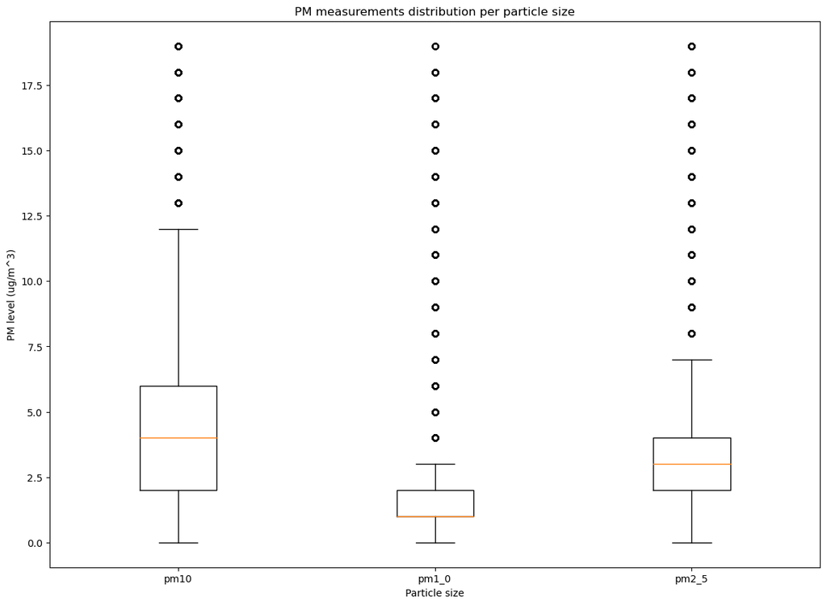

```python
plt.figure(figsize=(14,10))
low_thr = 20
aq_features = [air_quality_df[air_quality_df.pm10 < low_thr]['pm10'],
               air_quality_df[air_quality_df.pm1_0 < low_thr]['pm1_0'],
               air_quality_df[air_quality_df.pm2_5 < low_thr]['pm2_5']]
plt.boxplot(x=aq_features)
plt.title('PM measurements distribution per particle size')
plt.xlabel('Particle size')
plt.xticks([1, 2, 3], air_quality_df.columns[:3])
plt.ylabel('PM level (ug/m^3)')
plt.show()
```

```python
def boxplot_metrics(x):
    Q1 = x.quantile(0.25)
    Q3 = x.quantile(0.75)
    IQR = Q3 - Q1
    Lower_Fence = Q1 - (1.5 * IQR)
    Upper_Fence = Q3 + (1.5 * IQR)
    median = x.median()
    return [median, Q1, Q3, Upper_Fence]
```

```python
aq_table = pd.DataFrame(data=[boxplot_metrics(air_quality_df.pm10),
                              boxplot_metrics(air_quality_df.pm1_0),
                              boxplot_metrics(air_quality_df.pm2_5)],
                            columns= ['median', 'q1', 'q3', 'upper_fence'],
                                index = ['PM10', 'PM1.0', 'PM2.5'])
```

```python
def calculate_corrected_mean(x, u_f):
    return x[x <= u_f].mean()
```

```python
aq_table['corrected_mean'] = [calculate_corrected_mean(air_quality_df.pm10, aq_table.upper_fence[0]),
                              calculate_corrected_mean(air_quality_df.pm1_0, aq_table.upper_fence[1]),
                              calculate_corrected_mean(air_quality_df.pm2_5, aq_table.upper_fence[2])]
```

Let's summarize the relevant info from the plot above and add a corrected mean that discards the outliers.

```python
aq_table
```

|  | median | q1 | q3 | upper_fence | corrected_mean |
| --- | --- | --- | --- | --- | --- |
| PM10 | 4.0 | 2.0 | 6.0 | 12.0 | 4.271784 |
| PM1.0 | 1.0 | 1.0 | 2.0 | 3.5 | 1.474619 |
| PM2.5 | 3.0 | 2.0 | 4.0 | 7.0 | 2.834846 |

- PM10 is the measurement with the largest spread while PM1.0 the one with the lowest.
- For a typical week in February in Utrecht, the values in the table above seem reasonable and the corrected average values indicate good air quality if compared to the WHO recommended limits.

Let's now check VOC and NO2 behavior.

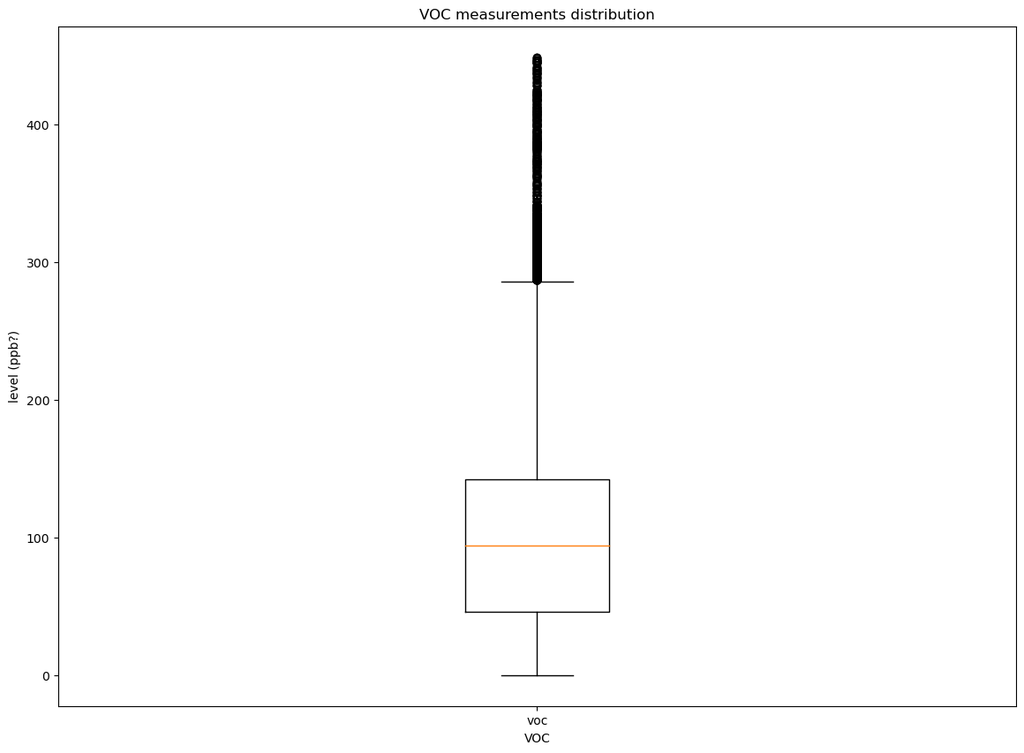

```python
plt.figure(figsize=(14,10))
aq_features = air_quality_df[air_quality_df.voc < 450]['voc']
plt.boxplot(x=aq_features)
plt.title('VOC measurements distribution')
plt.xlabel('VOC')
plt.xticks([1], air_quality_df.columns[3:4])
plt.ylabel('level (ppb?)')
plt.show()
```

```python
voc_table = pd.DataFrame(data=[boxplot_metrics(air_quality_df.voc)],
                            columns= ['median', 'q1', 'q3', 'upper_fence'],
                                index = ['VOC'])
```

```python
voc_table['corrected_mean'] = [calculate_corrected_mean(air_quality_df.voc, voc_table.upper_fence[0])]
```

```python
voc_table
```

|  | median | q1 | q3 | upper_fence | corrected_mean |
| --- | --- | --- | --- | --- | --- |
| VOC | 94.0 | 46.0 | 142.0 | 286.0 | 98.860089 |

- VOC measurements as well have plenty of outliers. It's not clear whether these are reasonable values for outdoor VOC and what VOC are being considered.

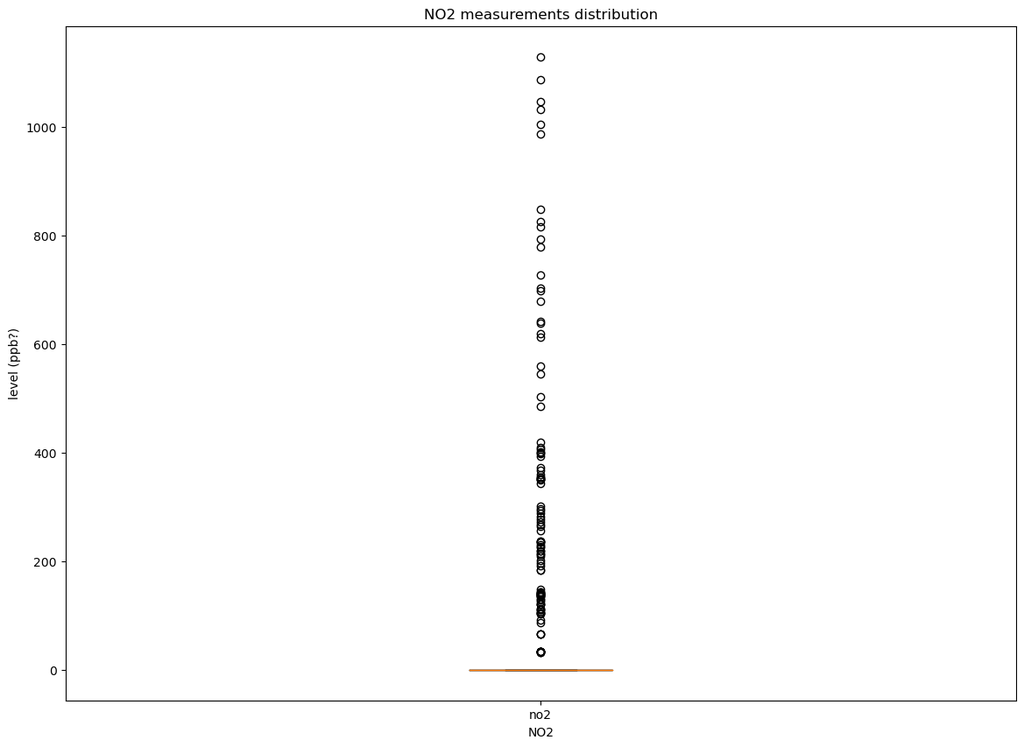

```python
plt.figure(figsize=(14,10))
aq_features = air_quality_df['no2']
plt.boxplot(x=aq_features)
plt.title('NO2 measurements distribution')
plt.xlabel('NO2')
plt.xticks([1], air_quality_df.columns[4:5])
plt.ylabel('level (ppb?)')
plt.show()
```

```python
no2_table = pd.DataFrame(data=[boxplot_metrics(air_quality_df.no2)],
                            columns= ['median', 'q1', 'q3', 'upper_fence'],
                                index = ['NO2'])
```

```python
no2_table['corrected_mean'] = [calculate_corrected_mean(air_quality_df.no2, no2_table.upper_fence[0])]
```

```python
no2_table
```

|  | median | q1 | q3 | upper_fence | corrected_mean |
| --- | --- | --- | --- | --- | --- |
| NO2 | 0.0 | 0.0 | 0.0 | 0.0 | 0.0 |

- NO2 meaurements seem to be to good to be true although it is indeed expected to have very low values as the SnifferBike sensors are probably deployed in areas where there are restrictions for diesel cars to move around, for example.

### Weather

Following a similar procedure we get the following results for the weather variables.

```python
weather_table
```

|  | median | q1 | q3 | upper_fence | corrected_mean |
| --- | --- | --- | --- | --- | --- |
| Pressure | 998.0 | 988.0 | 1011.0 | 1045.5 | 990.763804 |
| Temperature | 10.2 | 8.5 | 12.9 | 19.5 | 10.743589 |
| Humidity | 63.0 | 53.0 | 71.0 | 98.0 | 62.102570 |

- Weather data seems to be well aligned to winter weather in Utrecht. It would be interesting to check how this data while moving compares to *standstill* data.

# Conclusions

This EDA initally focuses on univariate analysis with the following main insights:

- SnifferBike users are mostly regular daily commuters who make little use of their bicycle during the weekend
- SnifferBike data is collected only during movement
- Air quality data presented large outliers which values indicate faulty sensors, corrupted data or acquistion issues. These issues don't seem to be represented by the error codes.
- When removing the outliers, air quality data seem to be realistic for a province like Utrecht

# Reccomendations

Based only on the above EDA and with the available information the following can be recommended:

- Data quantity and quality can be increased by involving bicycle users other than regular commuters
- Collecting data also while standing still may provide valuable info on air quality behavior in a single spot during the day
- Review logic for detecting data acquistion errors

# Open questions

The SnifferBike data is rich of features and hides many insights yet to explore. Some extra analysis with location data available may help answering the following questions:

- What's the expected PM in a given day, location, and weather?
- How does battery capacity may be optimized?
- Which are the most frequently used and better quality cycling routes?